# Cardiovascular risk prediction

JOSÉ LUIS

2024-10-16

# CÓDIGO

A través de este código se podrá ver como un preprocesamiento de los datos da lugar a un buen estudio exploratorio (EDA). Más adelante visualizaremos e indagaremos en la relación existente entre las variables para poder quedarnos con aquellas que pensamos que predicen mejor nuestra variable target (heart_disease) y asi, construir un modelo y evaluarlo para poder poner en manifiesto su precisión.

## LIBRERIAS

```r
library(caret)
library(ConfusionTableR)
library(DataExplorer)
library(dplyr)
library(ggplot2)
library(ggthemes)
library(kableExtra)
library(ModelMetrics)
library(openxlsx)
library(plotly)
library(probably)
library(pROC)
library(psych)
library(purrr)
library(randomForest)
library(reshape2)
library(skimr)
library(stringr)
library(tidymodels)
library(tidyverse)
library(univariateML)
library(vip)
library(xgboost)
library(WRS2)
library(GGally)
library(lmtest)
library(e1071)
library(fastDummies)
library(class)
library(ROCR)
library(corrplot)
library(vcd)
library(skimr)
```

## PRIMERA VISUALIZACIÓN

### DATASET Y VARIABLES

```r
data = read.csv("CVD_cleaned.csv")
head(data) %>% kable(format = "html") %>%
  kable_styling(bootstrap_options = c("striped", "hover", "condensed"),
                full_width = FALSE, position = "center", font_size = 12) %>%
  row_spec(0, background = "#287289", color = "white")
```

| General_Health | Checkup | Exercise | Heart_Disease | Skin_Cancer | Other_Cancer | Depression | Diabetes | Arthritis | Sex | Age_Category | Height_.cm. | Weight_.kg. | BMI | Smoking_History | Alcohol_Consumption | Fruit_Consumption | Green_Vegetables_Consumption | FriedPotato_Consumption |
| --- | --- | --- | --- | --- | --- | --- | --- | --- | --- | --- | --- | --- | --- | --- | --- | --- | --- | --- |
| Poor | Within the past 2 years | No | No | No | No | No | No | Yes | Female | 70-74 | 150 | 32.66 | 14.54 | Yes | 0 | 30 | 16 | 12 |
| Very Good | Within the past year | No | Yes | No | No | No | Yes | No | Female | 70-74 | 165 | 77.11 | 28.29 | No | 0 | 30 | 0 | 4 |
| Very Good | Within the past year | Yes | No | No | No | No | Yes | No | Female | 60-64 | 163 | 88.45 | 33.47 | No | 4 | 12 | 3 | 16 |
| Poor | Within the past year | Yes | Yes | No | No | No | Yes | No | Male | 75-79 | 180 | 93.44 | 28.73 | No | 0 | 30 | 30 | 8 |
| Good | Within the past year | No | No | No | No | No | No | No | Male | 80+ | 191 | 88.45 | 24.37 | Yes | 0 | 8 | 4 | 0 |
| Good | Within the past year | No | No | No | No | Yes | No | Yes | Male | 60-64 | 183 | 154.22 | 46.11 | No | 0 | 12 | 12 | 12 |

ECHAMOS UN VISTAZO A LAS COLUMNAS Y QUE TIPO DE DATOS REPRESENTAN

```r
colnames(data)
```

```
##  [1] "General_Health"               "Checkup"
##  [3] "Exercise"                     "Heart_Disease"
##  [5] "Skin_Cancer"                  "Other_Cancer"
##  [7] "Depression"                   "Diabetes"
##  [9] "Arthritis"                    "Sex"
## [11] "Age_Category"                 "Height_.cm."
## [13] "Weight_.kg."                  "BMI"
## [15] "Smoking_History"              "Alcohol_Consumption"
## [17] "Fruit_Consumption"            "Green_Vegetables_Consumption"
## [19] "FriedPotato_Consumption"
```

**VARIABLES:**

**General_Health:** Categoriga ordinal

**Checkup:** categorica nominal

**Exercise:** Binaria

**Heart_Disease:** Binaria

**Skin_Cancer:** Binaria

**Other_Cancer:** Binaria

**Depression:** Binaria

**Diabetes:** Categorica nominal

**Arthritis:** Binaria

**Sex:** Binaria

**Age_Category:** categorica ordinal

**Height_.cm.:** Numerica continua

**Weight_.kg.:** Numerica continua

**BMI:** Numerica continua

**Smoking_History:** Binaria

**Alcohol_Consumption:** numerica discreta

**Fruit_Consumption:** numerica discreta

**Green_Vegetables_Consumption:** numerica discreta

**FriedPotato_Consumption:** numerica discreta

### PREPROCESAMIENTO INICIAL

CONVERTIMOS LAS VARIABLES NECESARIAS A CATEGORICAS PARA 1) HACER GRÁFICOS NECESARIOS Y 2) UN BUEN PREPROCESAMIENTO AVANZADO PARA EL ESCALADO DE VARIABLES

```r
data$General_Health = as.factor(data$General_Health)
data$Checkup = as.factor(data$Checkup)
data$Exercise = as.factor(data$Exercise)
data$Skin_Cancer = as.factor(data$Skin_Cancer)
data$Other_Cancer = as.factor(data$Other_Cancer)
data$Depression = as.factor(data$Depression)
data$Diabetes = as.factor(data$Diabetes)
data$Arthritis = as.factor(data$Arthritis)
data$Sex = as.factor(data$Sex)
data$Age_Category = as.factor(data$Age_Category)
data$Smoking_History = as.factor(data$Smoking_History)
data$Heart_Disease = as.factor(data$Heart_Disease)
```

VAMOS A VER CUAL ES LA ESTRUCTURA DE NUESTRO DATASET

```r
str(data)
```

```
## 'data.frame':    308854 obs. of  19 variables:
##  $ General_Health              : Factor w/ 5 levels "Excellent","Fair",..: 4 5 5 4 3 3 2 3 2 2 ...
##  $ Checkup                     : Factor w/ 5 levels "5 or more years ago",..: 3 5 5 5 5 5 5 5 5 5 ...
##  $ Exercise                    : Factor w/ 2 levels "No","Yes": 1 1 2 2 1 1 2 2 1 1 ...
##  $ Heart_Disease               : Factor w/ 2 levels "No","Yes": 1 2 1 2 1 1 2 1 1 1 ...
##  $ Skin_Cancer                 : Factor w/ 2 levels "No","Yes": 1 1 1 1 1 1 1 1 1 1 ...
##  $ Other_Cancer                : Factor w/ 2 levels "No","Yes": 1 1 1 1 1 1 1 1 1 1 ...
##  $ Depression                  : Factor w/ 2 levels "No","Yes": 1 1 1 1 1 2 1 1 2 1 ...
##  $ Diabetes                    : Factor w/ 4 levels "No","No, pre-diabetes or borderline diabetes",..: 1 3 3 3 1 1 1 1 1 3 ...
##  $ Arthritis                   : Factor w/ 2 levels "No","Yes": 2 1 1 1 1 2 2 2 1 2 ...
##  $ Sex                         : Factor w/ 2 levels "Female","Male": 1 1 1 2 2 2 2 1 1 1 ...
##  $ Age_Category                : Factor w/ 13 levels "18-24","25-29",..: 11 11 9 12 13 9 9 10 10 11 ...
##  $ Height_.cm.                 : num  150 165 163 180 191 183 175 165 163 163 ...
##  $ Weight_.kg.                 : num  32.7 77.1 88.5 93.4 88.5 ...
##  $ BMI                         : num  14.5 28.3 33.5 28.7 24.4 ...
##  $ Smoking_History             : Factor w/ 2 levels "No","Yes": 2 1 1 1 2 1 2 2 2 1 ...
##  $ Alcohol_Consumption         : num  0 0 4 0 0 0 0 3 0 0 ...
##  $ Fruit_Consumption           : num  30 30 12 30 8 12 16 30 12 12 ...
##  $ Green_Vegetables_Consumption: num  16 0 3 30 4 12 8 8 12 12 ...
##  $ FriedPotato_Consumption     : num  12 4 16 8 0 12 0 8 4 1 ...
```

COMPROBAMOS SI HAY MISSING VALUES O DUPLICADOS Y LOS ELIMINAMOS EN CASO AFIRMATIVO.

```r
missing_values = colSums(is.na(data))
missing_values
```

```
##               General_Health                      Checkup
##                            0                            0
##                     Exercise                Heart_Disease
##                            0                            0
##                  Skin_Cancer                 Other_Cancer
##                            0                            0
##                   Depression                     Diabetes
##                            0                            0
##                    Arthritis                          Sex
##                            0                            0
##                 Age_Category                  Height_.cm.
##                            0                            0
##                  Weight_.kg.                          BMI
##                            0                            0
##              Smoking_History          Alcohol_Consumption
##                            0                            0
##            Fruit_Consumption Green_Vegetables_Consumption
##                            0                            0
##      FriedPotato_Consumption
##                            0
```

ES INTERESANTE NO SOLO COMPROBAR SI HAY MISSING VALUES, SINO TAMBIÉN COMPROBAR SI HAY DUPLICADOS PARA QUE NO HAYA RUIDO EN NUESTRO DATASET. HAY QUE TENER EN CUENTA TAMBIÉN EL NÚMERO DE DUPLICADOS QUE HAYA, PERO NUESTRO DATASET ES LO SUFICIENTEMENTE GRANDE COMO PARA QUE EL NUMERO DE DUPLICADOS NO NOS ALARME.

```r
# Verificar si hay duplicados
duplicados <- duplicated(data)
# Mostrar filas duplicadas
# data[duplicados, ] Escondo este paso para que no moleste en el html final
```

HEMOS GENERADO UNA TABLA QUE NOS INDICA LA POSICION (DE LA FILA) DEL DUPLICADO.

BORRAMOS LOS DUPLICADOS YA QUE 1) SON POCOS Y 2) PODRIAN GENERAR RUIDO INNECESARIO.

```r
data <- distinct(data)
```

## ANÁLISIS DESCRIPTIVO

USAREMOS PRIMERO UN SUMMARY, QUE ES UNA FORMA MÁS VULGAR DE VER NUESTROS DATOS Y LUEGO VAMOS A UTILIZAR LA FUNCION SKIM DEL PAQUETE SKIMR PARA VISUALIZARLOS DE UNA FORMA MÁS BONITA, CLARA Y PROFESIONAL, DENTRO DE QUE LO MÁS PROFESIONAL SIEMPRE SERÁ HACER LOS CALCULOS POR NOSOTROS MISMOS Y PRESENTARLOS EN UN DATAFRAME CON UN KABLE EXTRA. AQUI, YO LO HAGO ASI PARA AHORRAR TIEMPO Y, PORQUE EN ESENCIA, VA A MOSTRAR LO MISMO CON MENOS LINEAS DE CÓDIGO. SI QUISIERAMOS HACER UNA PRESENTACIÓN, UTILIZARIAMOS SIEMPRE OTROS MÉTODOS MÁS SOFISTICADOS.

```r
summary(data)
```

```
##    General_Health                      Checkup       Exercise     Heart_Disease
##  Excellent: 55929   5 or more years ago    : 13420   No : 69469   No :283803
##  Fair     : 35808   Never                  :  1407   Yes:239305   Yes: 24971
##  Good     : 95355   Within the past 2 years: 37210
##  Poor     : 11331   Within the past 5 years: 17442
##  Very Good:110351   Within the past year   :239295
##
##
##  Skin_Cancer  Other_Cancer Depression
##  No :278782   No :278897   No :246875
##  Yes: 29992   Yes: 29877   Yes: 61899
##
##
##
##
##
##                                        Diabetes      Arthritis
##  No                                        :259062   No :207711
##  No, pre-diabetes or borderline diabetes   :  6896   Yes:101063
##  Yes                                       : 40170
##  Yes, but female told only during pregnancy:  2646
##
##
##
##      Sex          Age_Category     Height_.cm.     Weight_.kg.
##  Female:160155   65-69  : 33425   Min.   : 91.0   Min.   : 24.95
##  Male  :148619   60-64  : 32409   1st Qu.:163.0   1st Qu.: 68.04
##                  70-74  : 31099   Median :170.0   Median : 81.65
##                  55-59  : 28048   Mean   :170.6   Mean   : 83.59
##                  50-54  : 25090   3rd Qu.:178.0   3rd Qu.: 95.25
##                  80+    : 22269   Max.   :241.0   Max.   :293.02
##                  (Other):136434
##       BMI        Smoking_History Alcohol_Consumption Fruit_Consumption
##  Min.   :12.02   No :183516      Min.   : 0.000      Min.   :  0.00
##  1st Qu.:24.21   Yes:125258      1st Qu.: 0.000      1st Qu.: 12.00
##  Median :27.44                   Median : 1.000      Median : 30.00
##  Mean   :28.63                   Mean   : 5.098      Mean   : 29.83
##  3rd Qu.:31.85                   3rd Qu.: 6.000      3rd Qu.: 30.00
##  Max.   :99.33                   Max.   :30.000      Max.   :120.00
##
##  Green_Vegetables_Consumption FriedPotato_Consumption
##  Min.   :  0.00               Min.   :  0.000
##  1st Qu.:  4.00               1st Qu.:  2.000
##  Median : 12.00               Median :  4.000
##  Mean   : 15.11               Mean   :  6.297
##  3rd Qu.: 20.00               3rd Qu.:  8.000
##  Max.   :128.00               Max.   :128.000
##
```

SKIM

```r
skim(data)
```

Data summary

| Name | data |
| --- | --- |
| Number of rows | 308774 |
| Number of columns | 19 |
| _______________________ |  |
| Column type frequency: |  |
| factor | 12 |
| numeric | 7 |
| ________________________ |  |
| Group variables | None |

**Variable type: factor**

| skim_variable | n_missing | complete_rate | ordered | n_unique | top_counts |
| --- | --- | --- | --- | --- | --- |
| General_Health | 0 | 1 | FALSE | 5 | Ver: 110351, Goo: 95355, Exc: 55929, Fai: 35808 |
| Checkup | 0 | 1 | FALSE | 5 | Wit: 239295, Wit: 37210, Wit: 17442, 5 o: 13420 |
| Exercise | 0 | 1 | FALSE | 2 | Yes: 239305, No: 69469 |
| Heart_Disease | 0 | 1 | FALSE | 2 | No: 283803, Yes: 24971 |
| Skin_Cancer | 0 | 1 | FALSE | 2 | No: 278782, Yes: 29992 |
| Other_Cancer | 0 | 1 | FALSE | 2 | No: 278897, Yes: 29877 |
| Depression | 0 | 1 | FALSE | 2 | No: 246875, Yes: 61899 |
| Diabetes | 0 | 1 | FALSE | 4 | No: 259062, Yes: 40170, No,: 6896, Yes: 2646 |
| Arthritis | 0 | 1 | FALSE | 2 | No: 207711, Yes: 101063 |
| Sex | 0 | 1 | FALSE | 2 | Fem: 160155, Mal: 148619 |
| Age_Category | 0 | 1 | FALSE | 13 | 65-: 33425, 60-: 32409, 70-: 31099, 55-: 28048 |
| Smoking_History | 0 | 1 | FALSE | 2 | No: 183516, Yes: 125258 |

**Variable type: numeric**

| skim_variable | n_missing | complete_rate | mean | sd | p0 | p25 | p50 | p75 | p100 | hist |
| --- | --- | --- | --- | --- | --- | --- | --- | --- | --- | --- |
| Height_.cm. | 0 | 1 | 170.62 | 10.66 | 91.00 | 163.00 | 170.00 | 178.00 | 241.00 | ▁▁▇▂▁ |
| Weight_.kg. | 0 | 1 | 83.59 | 21.34 | 24.95 | 68.04 | 81.65 | 95.25 | 293.02 | ▇▇▁▁▁ |
| BMI | 0 | 1 | 28.63 | 6.52 | 12.02 | 24.21 | 27.44 | 31.85 | 99.33 | ▇▅▁▁▁ |
| Alcohol_Consumption | 0 | 1 | 5.10 | 8.20 | 0.00 | 0.00 | 1.00 | 6.00 | 30.00 | ▇▁▁▁▁ |
| Fruit_Consumption | 0 | 1 | 29.83 | 24.88 | 0.00 | 12.00 | 30.00 | 30.00 | 120.00 | ▇▆▃▁▁ |
| Green_Vegetables_Consumption | 0 | 1 | 15.11 | 14.93 | 0.00 | 4.00 | 12.00 | 20.00 | 128.00 | ▇▂▁▁▁ |
| FriedPotato_Consumption | 0 | 1 | 6.30 | 8.58 | 0.00 | 2.00 | 4.00 | 8.00 | 128.00 | ▇▁▁▁▁ |

## VISUALIZACIÓN DE LOS DATOS

### VARIABLES NUMERICAS - TARGET - BOXPLOT

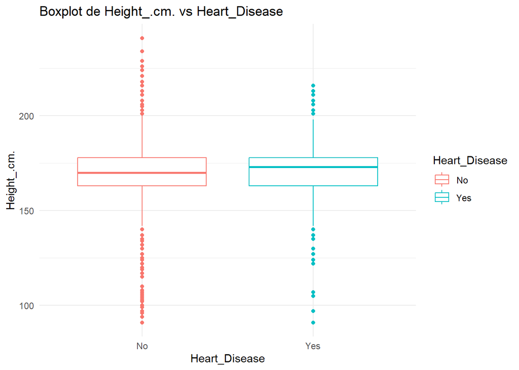

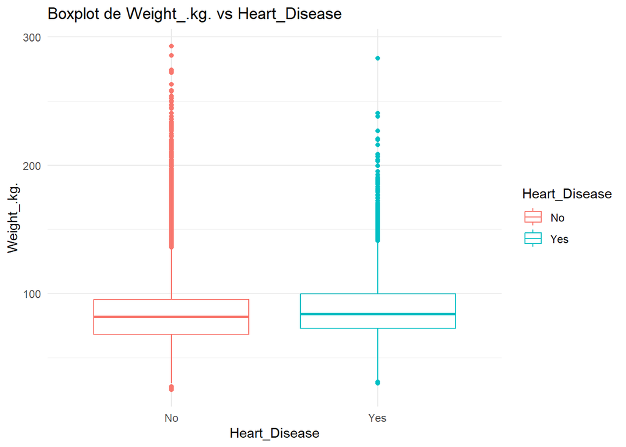

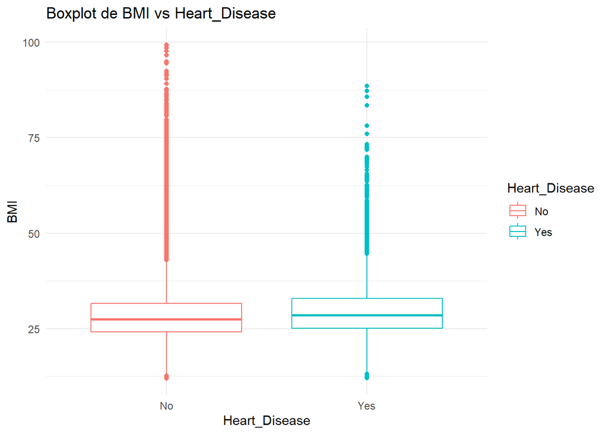

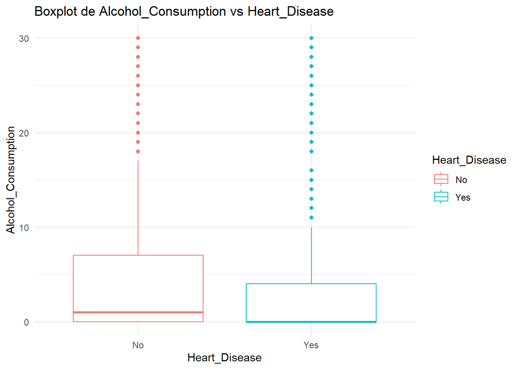

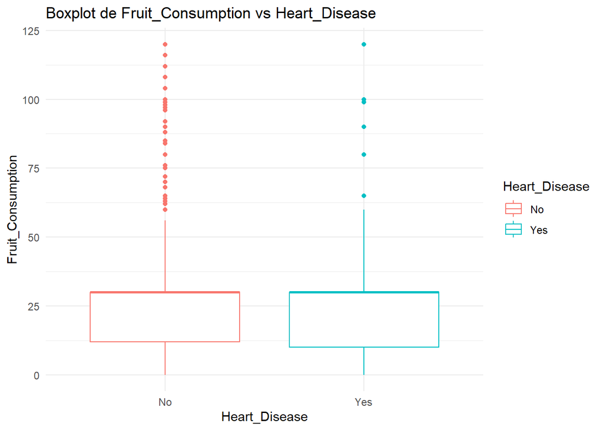

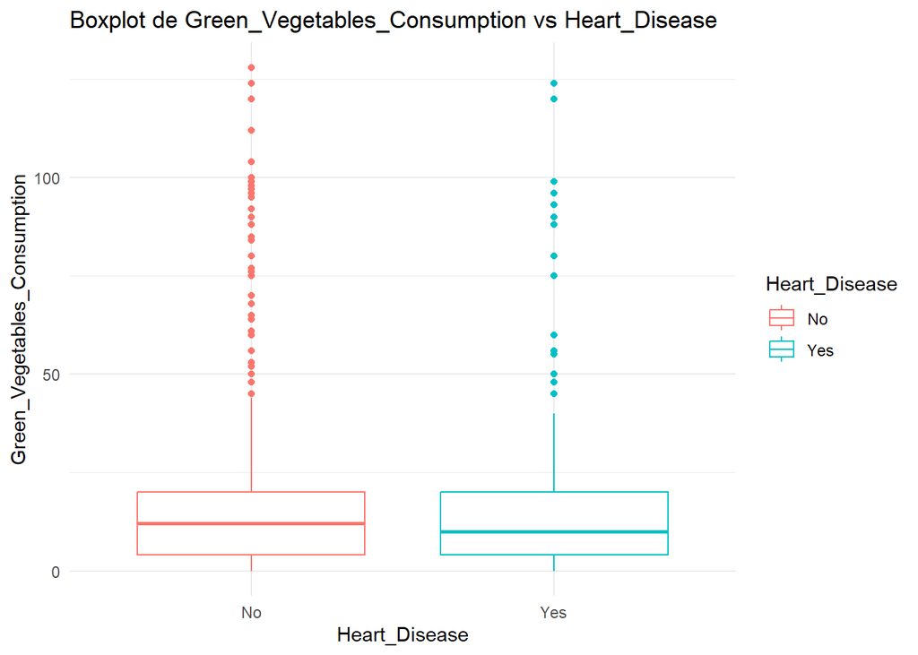

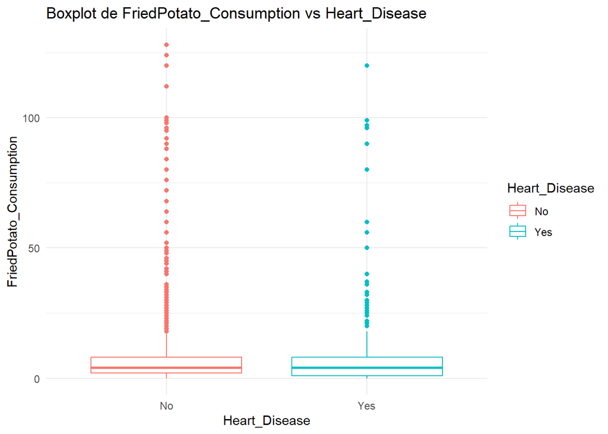

```r
variables_numericas = data %>%
  select(where(is.numeric))

# Hacemos un boxplot sencillo
for (var in colnames(variables_numericas)) {
  g = ggplot(data, aes(x = Heart_Disease, y = variables_numericas[[var]], col = Heart_Disease)) +
    geom_boxplot() +
    theme_minimal() +
    labs(x = "Heart_Disease", y = var) +
    ggtitle(paste("Boxplot de", var, "vs Heart_Disease"))

  print(g)

}
```

NO VEMOS APENAS DIEFERENCIAS SIGNIFICATIVAS EN LAS VARIABLES NUMERICAS. AUNQUE, LO QUE SI ES INTERESANTE, ES EL NÚMERO TAN ELEVADO DE OUTLIERS QUE HAY. EN UN DATASET CON TANTAS OBSERVACIONES Y CON VARIABLES COMO PUEDEN SER PESO, ALTURA, BMI, ETC SEGURO QUE HABRÁ ERRORES EN LA MEDICIÓN. PERO TENEMOS QUE PENSAR, ¿SON TAN GRANDES LOS ERRORES COMO PARA QUE CONSTITUYAN VALORES ATIPICOS O SON SIMPLES DATOS REALES QUE SE SALEN DE LO COMÚN? BIEN, LO QUE SE HARÁ EN ESTE ESTUDIO ES HACER MODELOS CON Y SIN OUTLIERS Y VER LAS DIFERENCIAS PARA ASI QUITARNOS LAS POSIBLES DUDAS.

A CONTINUACIÓN, SE PRESENTARÁN OTRA FORMA DE VISUALIZAR LOS DATOS

### VARIABLES NUMERICAS - TARGET - VIOLIN PLOT

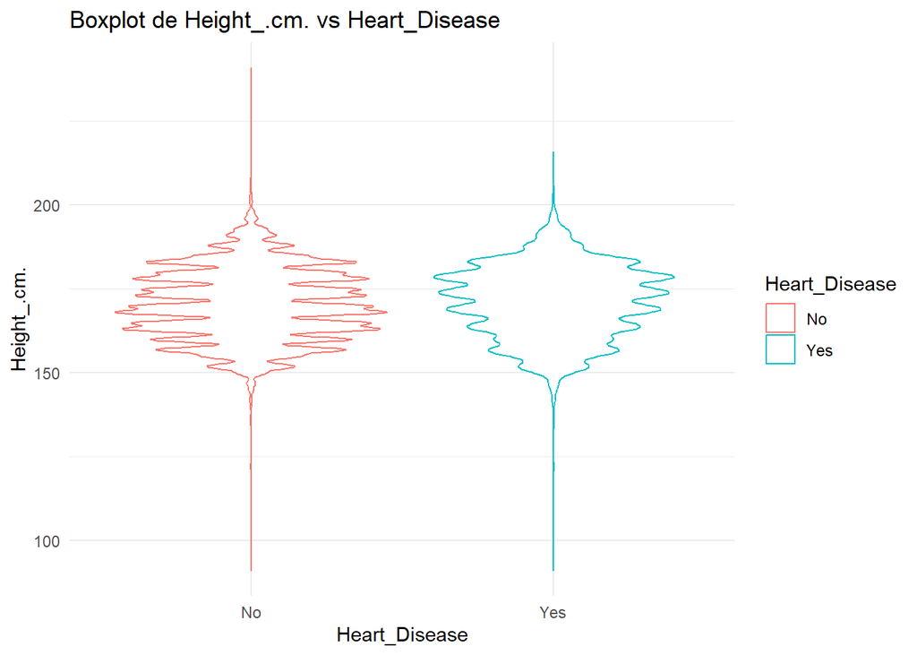

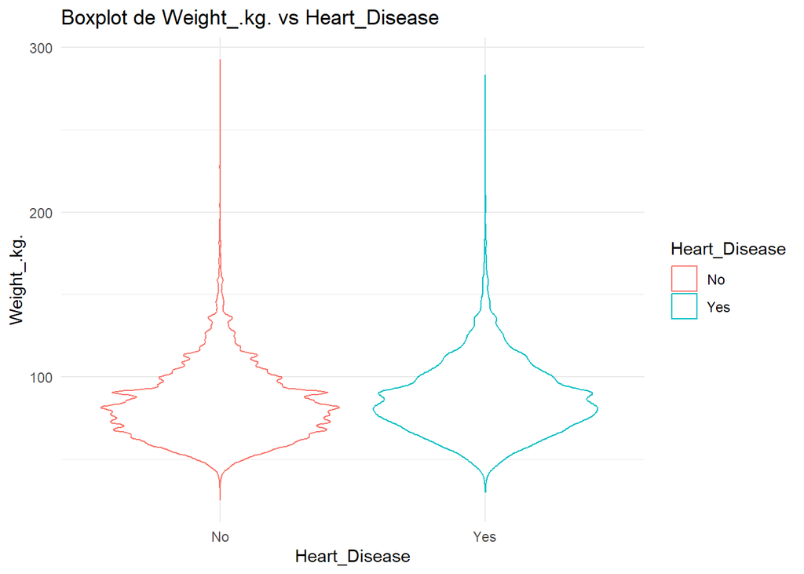

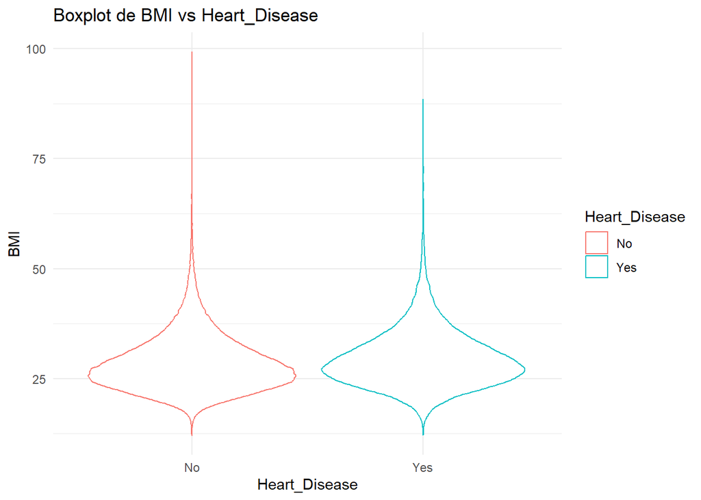

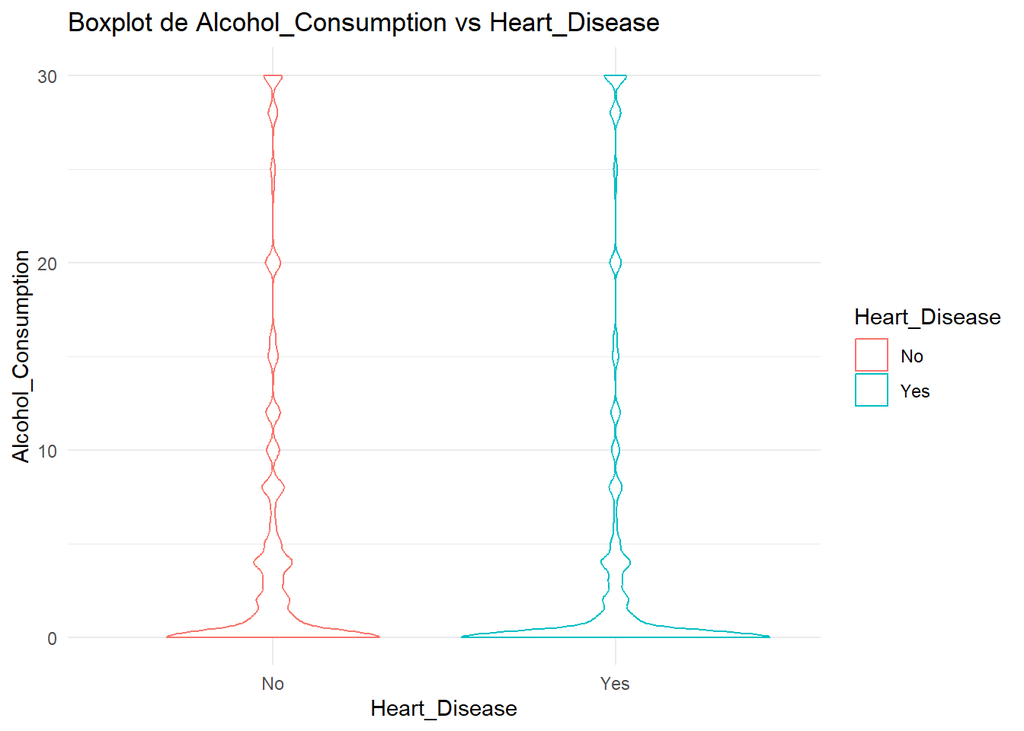

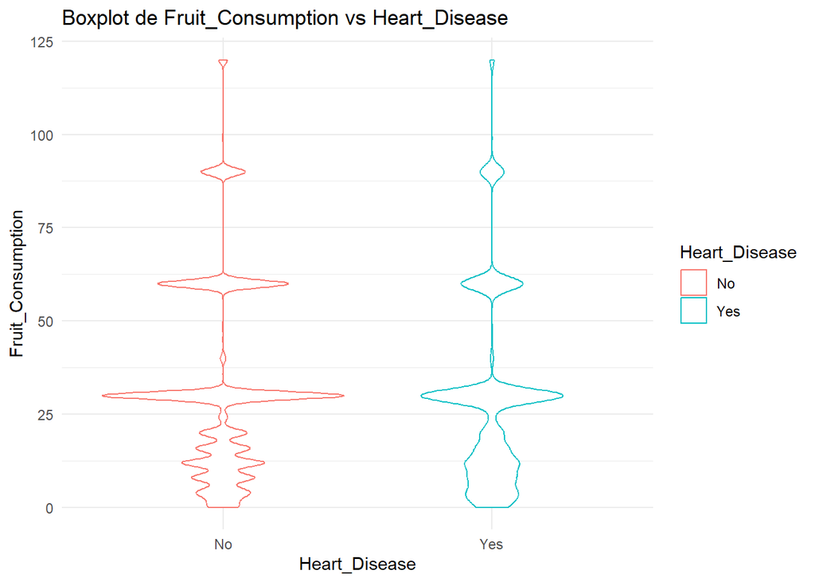

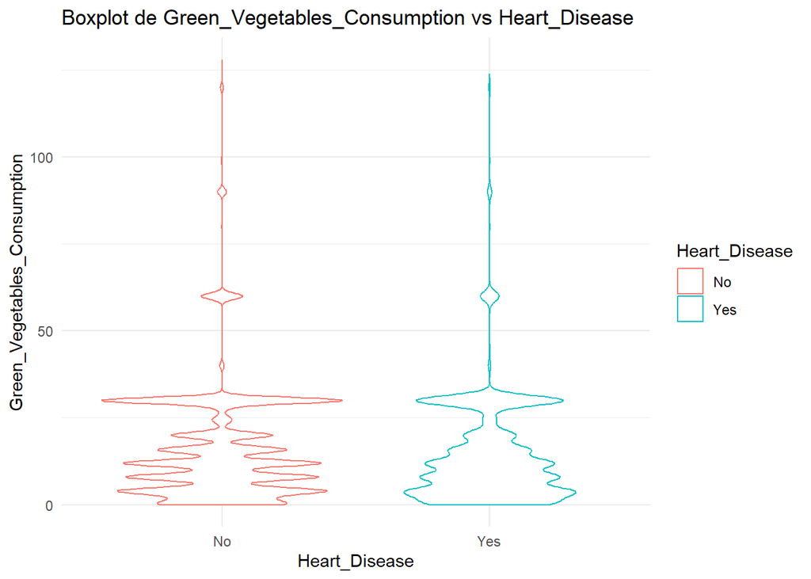

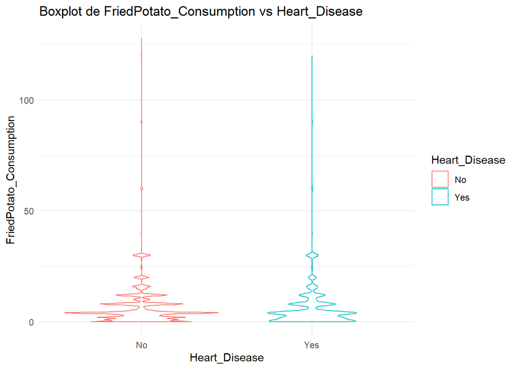

```r
variables_numericas = data %>%
  select(where(is.numeric))

# Hacemos un violin plot sencillo
for (var in colnames(variables_numericas)) {
  g = ggplot(data, aes(x = Heart_Disease, y = variables_numericas[[var]], col = Heart_Disease)) +
    geom_violin() +
    theme_minimal() +
    labs(x = "Heart_Disease", y = var) +
    ggtitle(paste("Boxplot de", var, "vs Heart_Disease"))

  print(g)

}
```

AHORA VAMOS A VISUALIZAR LAS VARIABLES CATEGORICAS

### VARIABLES CATEGORICAS - TARGET - GRAFICO DE BARRAS

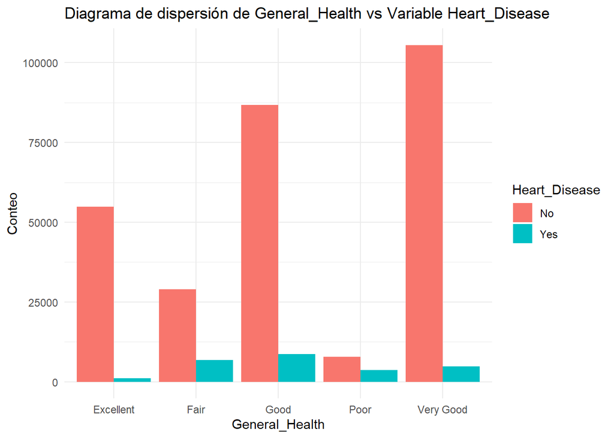

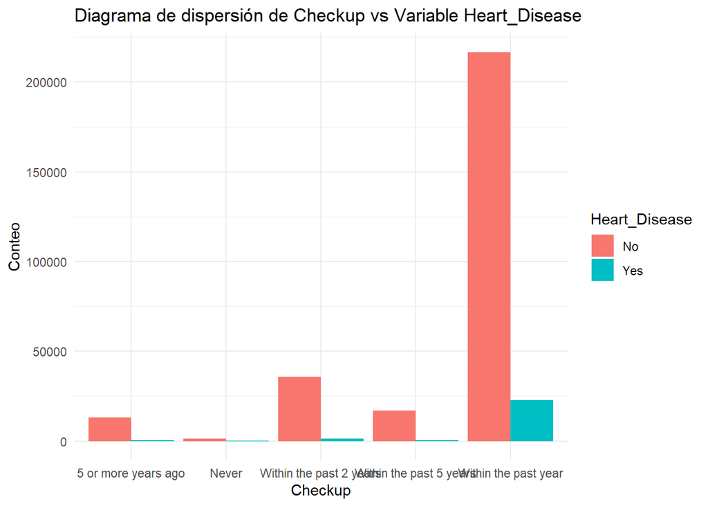

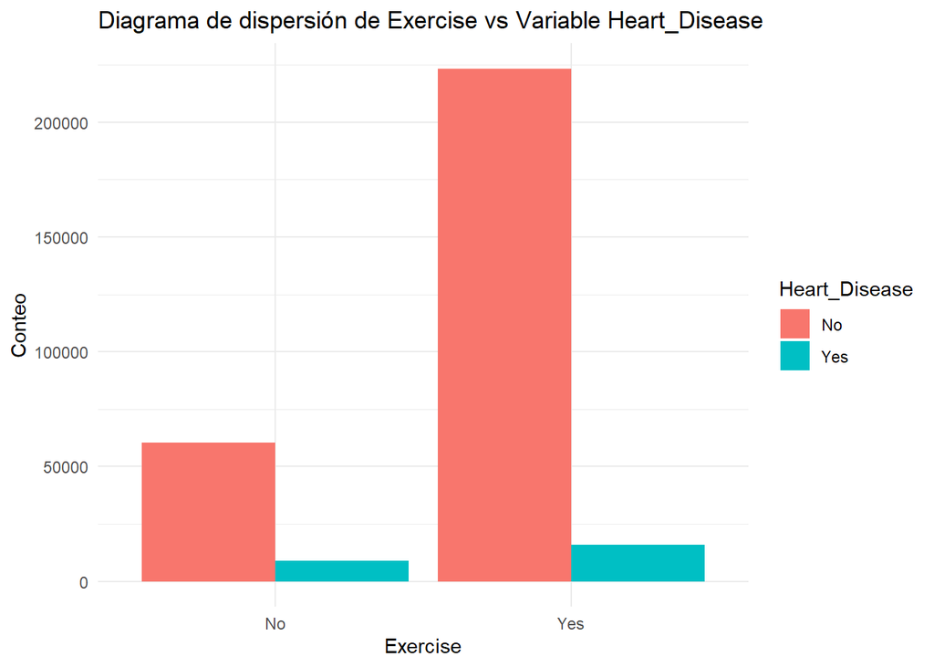

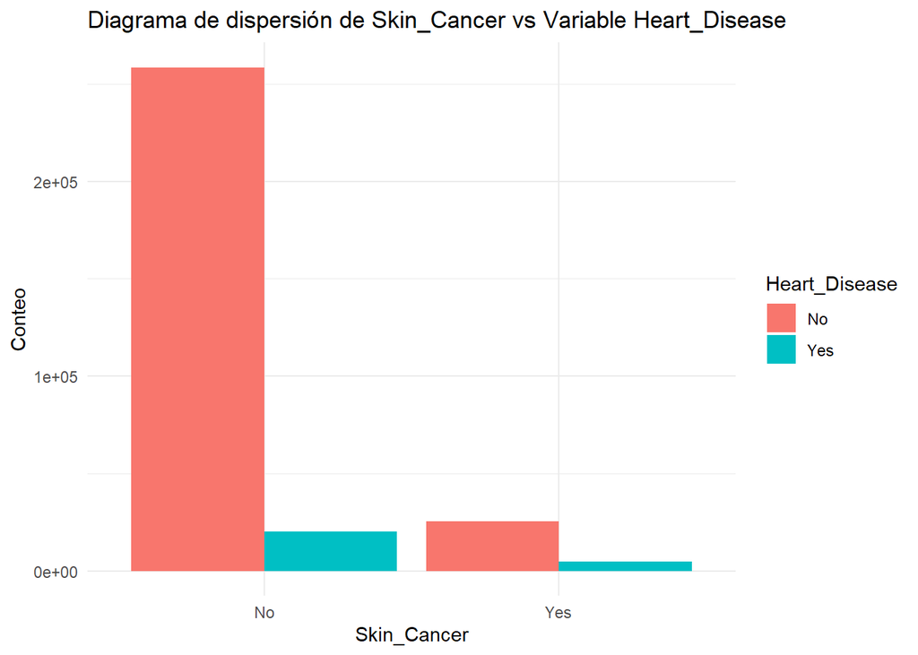

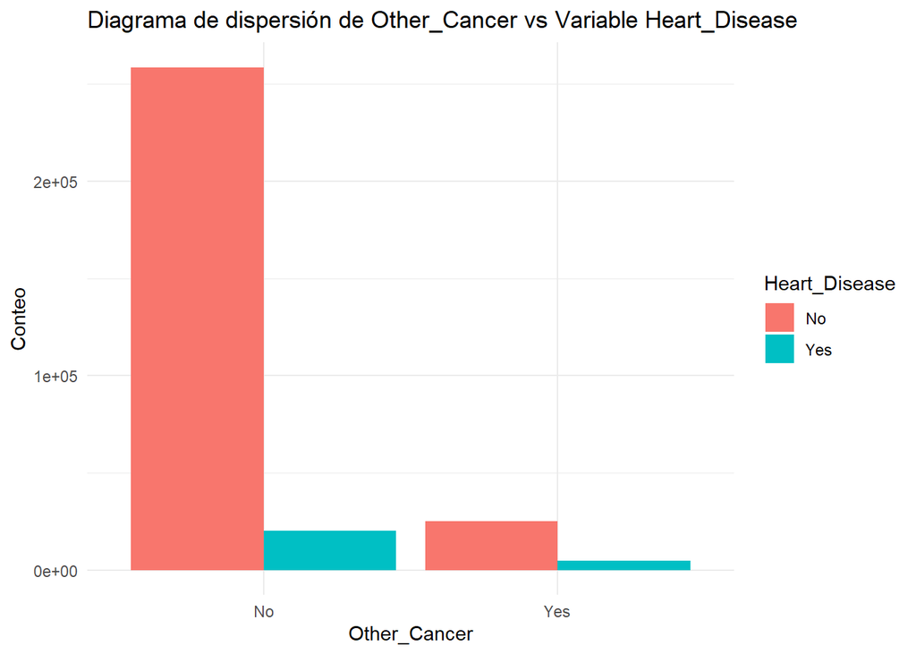

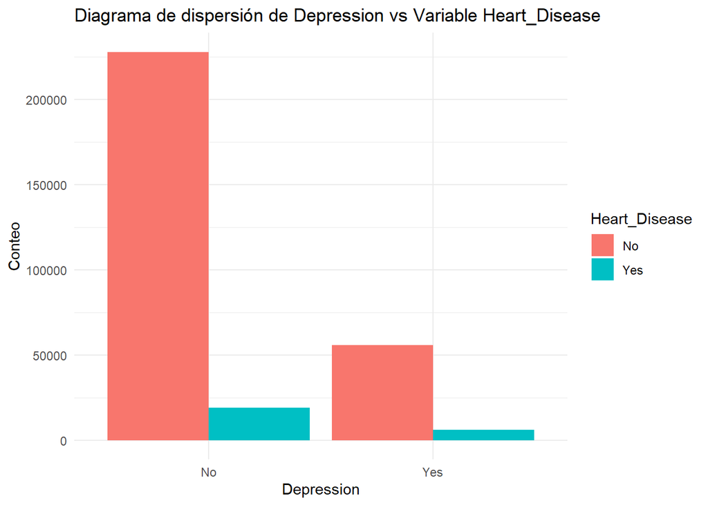

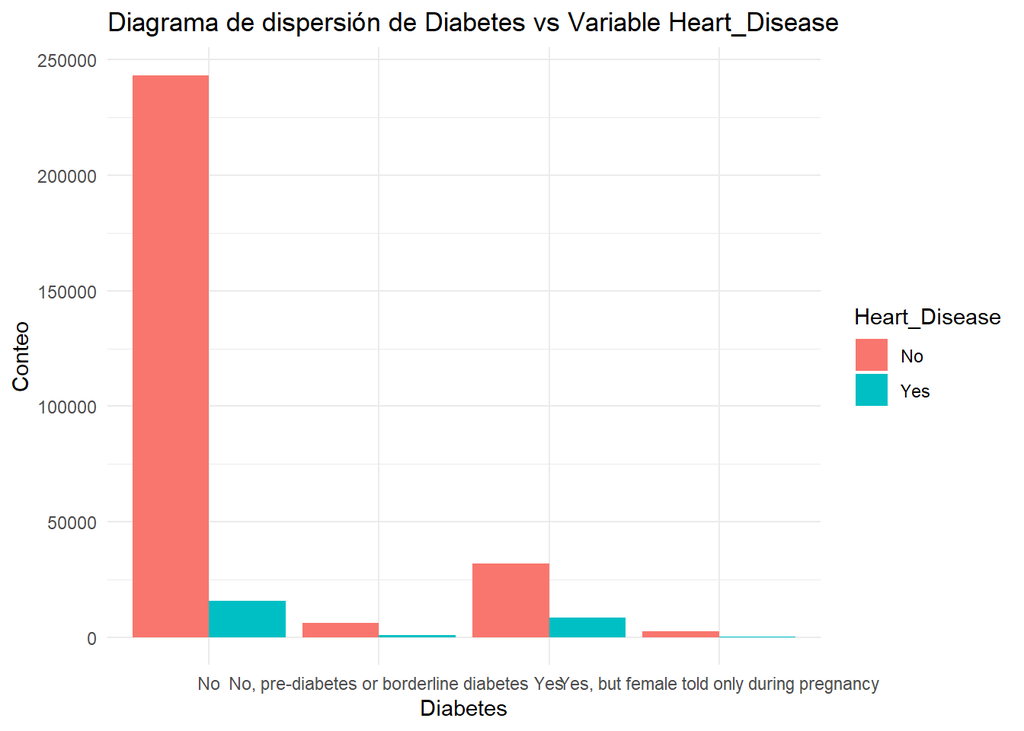

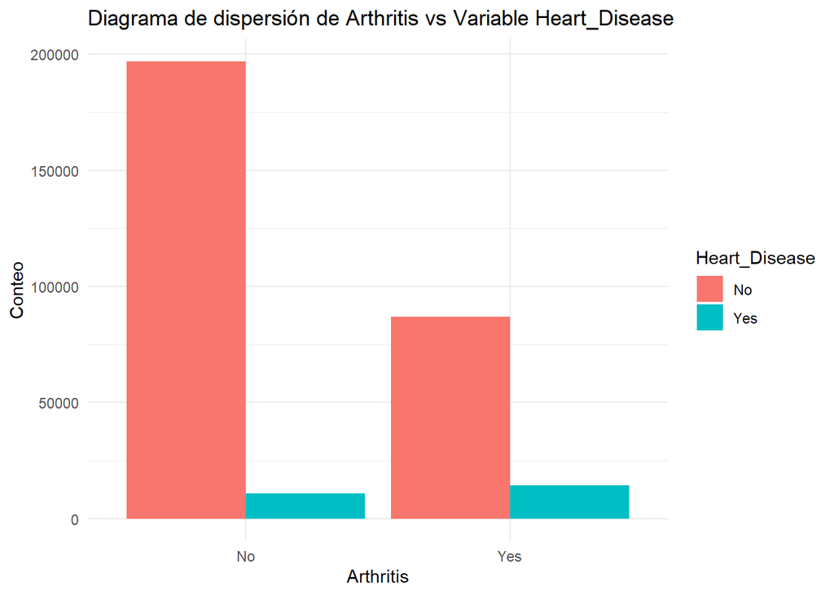

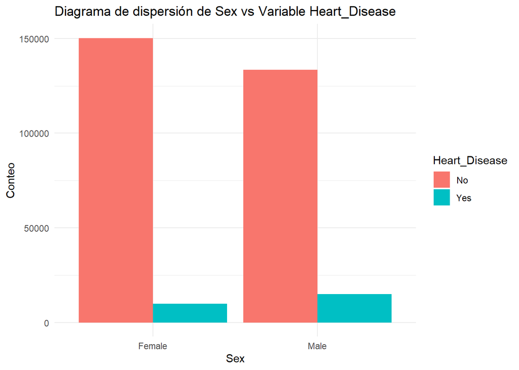

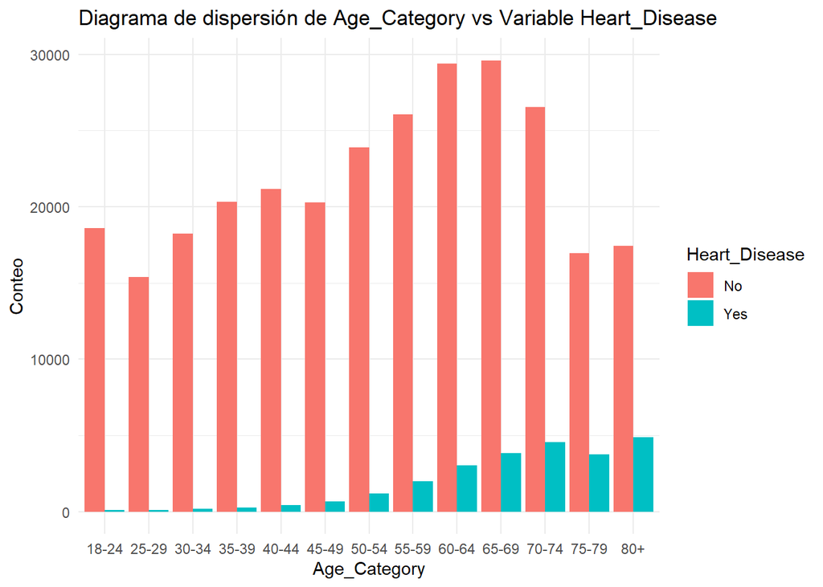

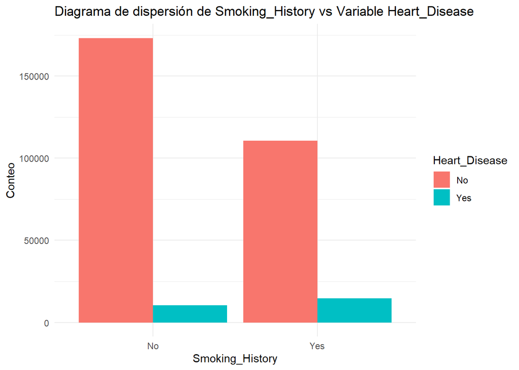

```r
variables_categoricas = data %>%
  select(where(is.factor))

for (var in colnames(variables_categoricas)) {
  # Hacemos un condicional para que cuando toque hearth_disease, no haga el gráfico
  if (var == "Heart_Disease") next

  g = ggplot(data, aes(x = variables_categoricas[[var]], fill = Heart_Disease)) +
    theme_minimal() +
    geom_bar(position = "dodge") +
    labs(x = var, y = "Conteo", fill = "Heart_Disease") +
    ggtitle(paste("Diagrama de dispersión de", var, "vs Variable Heart_Disease"))

  print(g)

}
```

EN ESTOS GRÁFICOS SI QUE HAY RESULTADOS MÁS INTERESANTES. POR EJEMPLO, VEMOS QUE LA SALUD GENERAL SI INCIDE EN ENFERMEDADES CARDIOVASCULARES, SIENDO QUE EXCELLENT ES EL QUE MENOS CASOS TIENE. LA EDAD PARECE TAMBIEN SER SIGNIFICATIVA, PUES A MEDIDA QUE AUMENTADOS LA EDAD, LOS CASOS TAMBIÉN AUMENTAN. PARECE QUE EL SEXO PODRIA SER IMPORTANTE, PUES HAY MÁS HOMBRES QUE MUJERES, AUNQUE EL AUMENTO NO PARECE SER MUY SIGNIFICATIVO.

A CONTINUACIÓN, SE VERÁN OTRAS FORMAS DE VISUALIZAR COMO LAS VARIABLES CATEGORICAS SE COMPORTAN CONTRA LA VARIABLE TARGET